# Example analysis for Reproducible Reporting using Markdown

Meta Miriam Bönniger

04 Juli, 2021

```r
knitr::opts_chunk$set(echo = TRUE)
```

## Load/install packages

```r
list.of.packages <- c("patchwork", "ggpubr", "tidyverse", "data.table", "knitr", "markdown", "rmarkdown", "dplyr", "ggplot2", "moments", "car")

# install packages if new
new.packages <- list.of.packages[!(list.of.packages %in% installed.packages()[,"Package"])]
if(length(new.packages)) install.packages(new.packages)

# load packages
invisible(lapply(list.of.packages, library, character.only = TRUE))
```

## Download dataset for analysis

Download and save the dataset for the analysis of: http://www.oasis-brains.org/pdf/oasis_longitudinal.csv

Dataset description and explanation:

Open Access Series of Imaging Studies (OASIS): Longitudinal MRI Data in Nondemented and Demented Older Adults. Marcus, DS, Fotenos, AF, Csernansky, JG, Morris, JC, Buckner, RL, 2010. Journal of Cognitive Neuroscience, 22, 2677-2684. doi: 10.1162/jocn.2009.21407

```r
#set working directory
setwd("/Users/boennigerm/Desktop/DEMON_reproducible-science")

#load dataset
dt.raw <- read.csv("oasis_longitudinal.csv")

#load data dictionary
dt.dict <- read.csv("Data-dictionary.csv")
```

## Changing variable type

1. We change the values of CDR from numeric values to ordered factors as suggested by the data dictionary.
- 0 = no dementia
- 0.5 = very mild AD
- 1 = mild AD
- 2 = moderate AD

```r
dt <- dt.raw %>%
  mutate(CDR =
           factor(ifelse(CDR == 0,
                         "no dementia",
                         ifelse(CDR == 0.5,
                                "very mild AD",
                                ifelse(CDR == 1,
                                       "mild AD",
                                       ifelse(CDR == 2,
                                              "moderate AD",
                                              NA)))),
                  levels=c("no dementia", "very mild AD", "mild AD", "moderate AD"),
                  ordered=TRUE))
```

2. We change “Visit” from numeric values to ordered factors (1-5).

```r
dt <- dt %>%
  mutate(Visit = factor(Visit,
                        levels=c(1,2,3,4,5),
                        ordered=TRUE))
```

3. We change “SES” from numeric values to ordered factors (1 = highest to 5 = lowest status).

```r
dt <- dt %>%
  mutate(SES = factor(SES,
                      levels=c(1,2,3,4,5),
                      ordered=TRUE))
```

## Getting an overview about the dataset

### Non-numerical variables

```r
numeric.var <- dt[, sapply(dt, is.numeric)] %>%
  names()

kable(head(dt %>%
             dplyr::select(-all_of(numeric.var))) %>%
        data.frame(),
      caption = "Head of all non-numeric variables in the dataset.")
```

Head of all non-numeric variables in the dataset.

| Subject.ID | MRI.ID | Group | Visit | M.F | Hand | SES | CDR |
| --- | --- | --- | --- | --- | --- | --- | --- |
| OAS2_0001 | OAS2_0001_MR1 | Nondemented | 1 | M | R | 2 | no dementia |
| OAS2_0001 | OAS2_0001_MR2 | Nondemented | 2 | M | R | 2 | no dementia |
| OAS2_0002 | OAS2_0002_MR1 | Demented | 1 | M | R | NA | very mild AD |
| OAS2_0002 | OAS2_0002_MR2 | Demented | 2 | M | R | NA | very mild AD |
| OAS2_0002 | OAS2_0002_MR3 | Demented | 3 | M | R | NA | very mild AD |
| OAS2_0004 | OAS2_0004_MR1 | Nondemented | 1 | F | R | 3 | no dementia |

```r
kable(table(dt$Group, useNA = "ifany") %>%
        data.frame() %>%
        dplyr::rename(Group = Var1),
      caption = "Factor levels and frequency of variable 'Group'")
```

Factor levels and frequency of variable ‘Group’

| Group | Freq |
| --- | --- |
| Converted | 37 |
| Demented | 146 |
| Nondemented | 190 |

```r
kable(table(dt$Visit, useNA = "ifany") %>%
        data.frame() %>%
        dplyr::rename(Visit = Var1),
      caption = "Factor levels and frequency of variable 'Visit'")
```

Factor levels and frequency of variable ‘Visit’

| Visit | Freq |
| --- | --- |
| 1 | 150 |
| 2 | 144 |
| 3 | 58 |
| 4 | 15 |
| 5 | 6 |

```r
kable(table(dt$M.F, useNA = "ifany") %>%
        data.frame() %>%
        dplyr::rename(M.F = Var1),
      caption = "Factor levels and frequency of variable 'M.F'")
```

Factor levels and frequency of variable ‘M.F’

| M.F | Freq |
| --- | --- |
| F | 213 |
| M | 160 |

```r
kable(table(dt$Hand, useNA = "ifany") %>%
        data.frame() %>%
        dplyr::rename(Hand = Var1),
      caption = "Factor levels and frequency of variable 'Hand'")
```

Factor levels and frequency of variable ‘Hand’

| Hand | Freq |
| --- | --- |
| R | 373 |

```r
kable(table(dt$SES, useNA = "ifany") %>%
        data.frame() %>%
        dplyr::rename(SES = Var1),
      caption = "Factor levels and frequency of variable 'SES'")
```

Factor levels and frequency of variable ‘SES’

| SES | Freq |
| --- | --- |
| 1 | 88 |
| 2 | 103 |
| 3 | 82 |
| 4 | 74 |
| 5 | 7 |
| NA | 19 |

```r
kable(table(dt$CDR, useNA = "ifany") %>%
        data.frame() %>%
        dplyr::rename(CDR = Var1),
      caption = "Factor levels and frequency of variable 'CDR'")
```

Factor levels and frequency of variable ‘CDR’

| CDR | Freq |
| --- | --- |
| no dementia | 206 |
| very mild AD | 123 |
| mild AD | 41 |
| moderate AD | 3 |

### Numerical variables

```r
kable(dt %>%
        dplyr::select(all_of(numeric.var)) %>%
        summary() %>%
        data.frame() %>%
        dplyr::select(-Var1) %>%
        dplyr::rename(Variable = Var2) %>%
        dplyr::mutate(Freq = gsub(" ", "", Freq, fixed = TRUE),
                      Freq = gsub("\'", "", Freq, fixed = TRUE)) %>%
        filter(!is.na(Freq)) %>%
        separate(Freq, c("V1", "V2"), sep= ":") %>%
        group_by(Variable) %>%
        spread(V1, V2),
      caption = "Summary of all numeric variables in the dataset")
```

Summary of all numeric variables in the dataset

| Variable | 1stQu. | 3rdQu. | Max. | Mean | Median | Min. | NAs |
| --- | --- | --- | --- | --- | --- | --- | --- |
| MR.Delay | 0.0 | 873.0 | 2639.0 | 595.1 | 552.0 | 0.0 | NA |
| Age | 71.00 | 82.00 | 98.00 | 77.01 | 77.00 | 60.00 | NA |
| EDUC | 12.0 | 16.0 | 23.0 | 14.6 | 15.0 | 6.0 | NA |
| MMSE | 27.00 | 30.00 | 30.00 | 27.34 | 29.00 | 4.00 | 2 |
| eTIV | 1357 | 1597 | 2004 | 1488 | 1470 | 1106 | NA |
| nWBV | 0.7000 | 0.7560 | 0.8370 | 0.7296 | 0.7290 | 0.6440 | NA |
| ASF | 1.099 | 1.293 | 1.587 | 1.195 | 1.194 | 0.876 | NA |

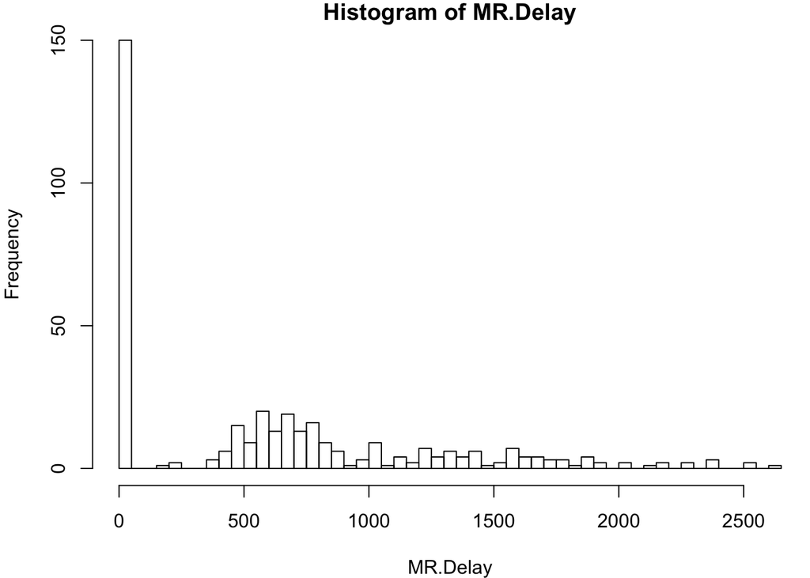

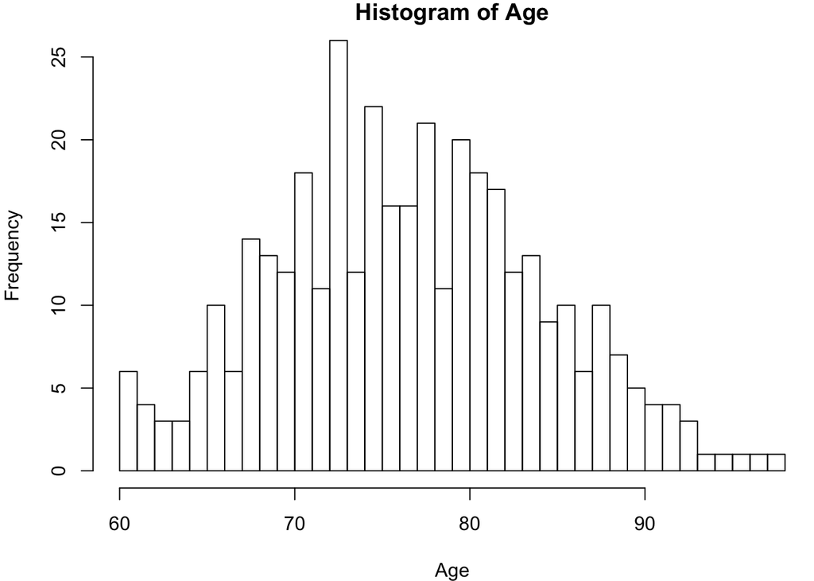

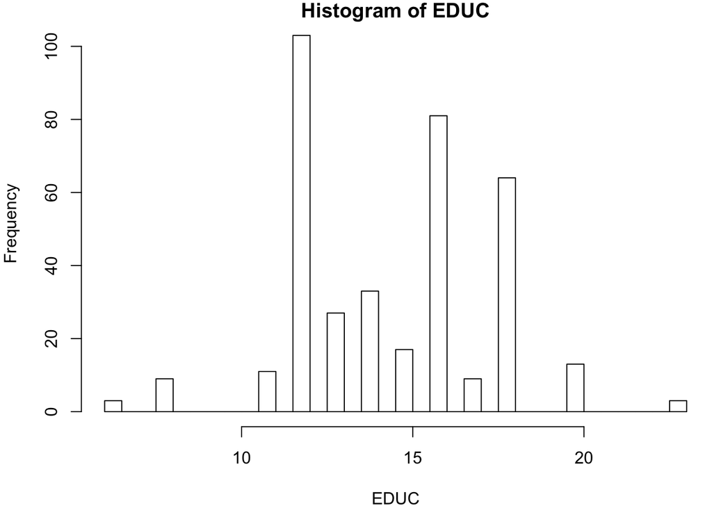

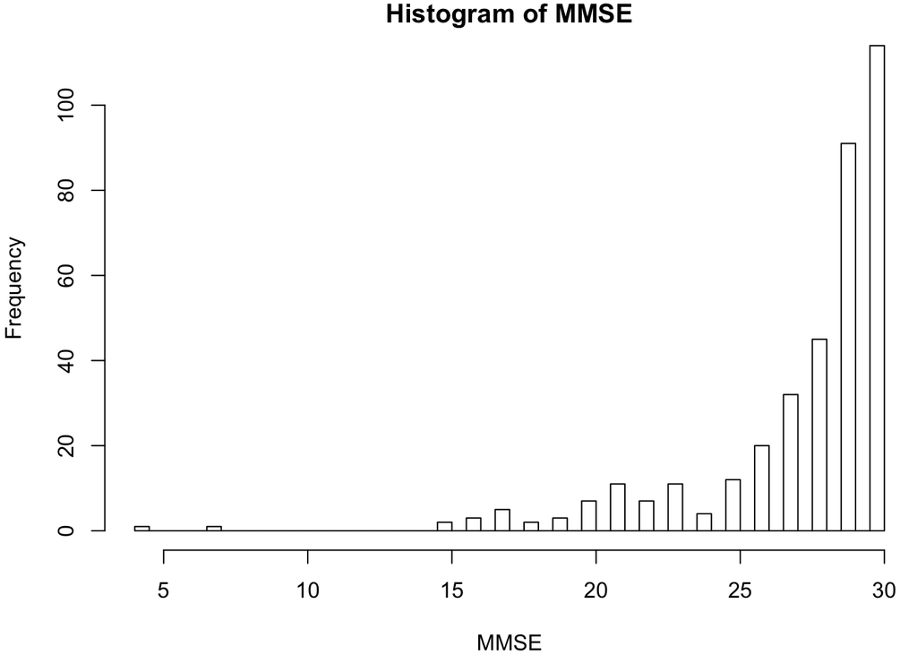

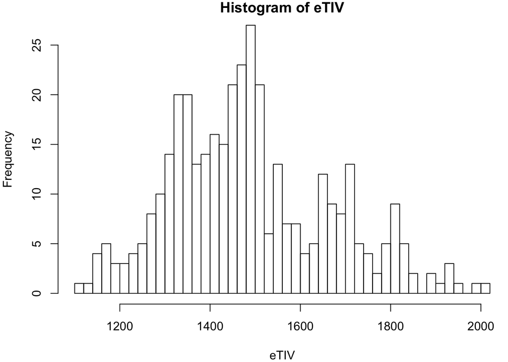

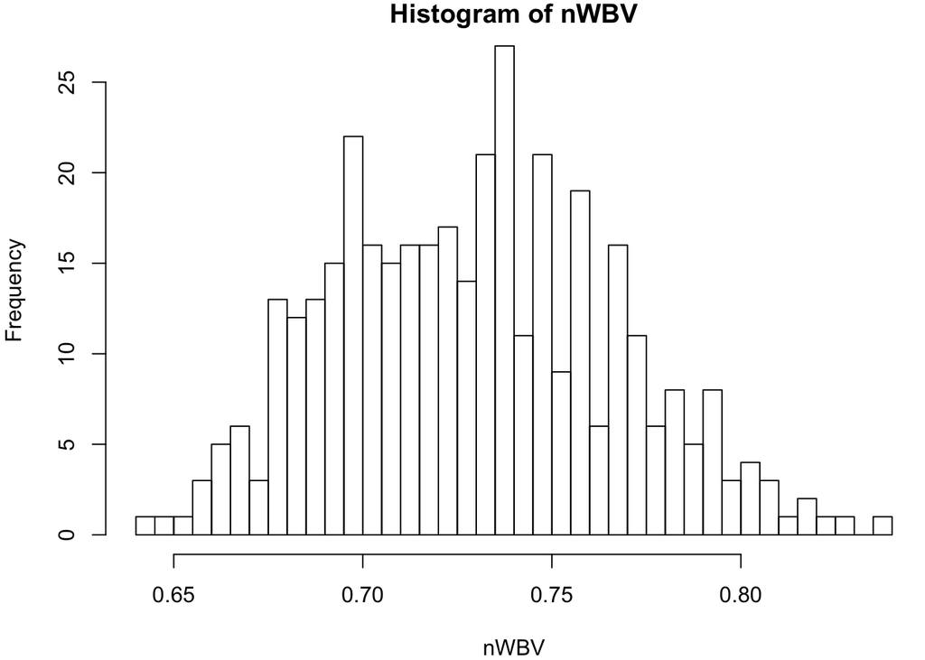

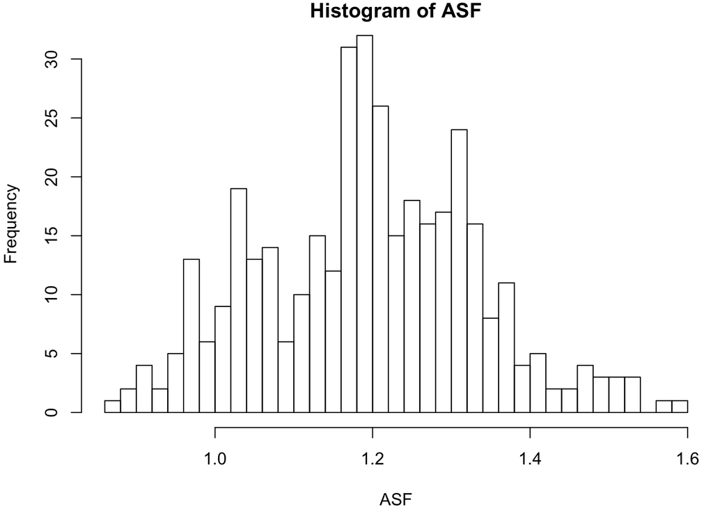

```r
#fig.show="hold",  suppress = T
par(mar = c(4, 4, 1, .1))
#distribution
distribution_check_plots <- function(variable) {
  a <- dt %>% filter(!is.na(.[[variable]]))

  hist(a[[variable]],
       breaks = 50,
       xlab = paste0(variable),
       main = paste0("Histogram of ", variable))
}

invisible(lapply(numeric.var,distribution_check_plots))
```

## Table 1

Create a typical table one. Show it in this Markdown and save it also as csv for integrating it, for example, into a manuscript.

```r
# 1. Select variables for table
myVars <- names(dt %>%
                  dplyr::select(-Subject.ID, -MRI.ID))


# 2. Make a list of all categorical variables from the myVars list for this table
catVars <- dt %>%
  dplyr::select(all_of(myVars)) %>%
  dplyr::select_if(purrr::negate(is.numeric)) %>%
  names()

# 3. Check visually for non-normally distributed numerical variables
#hist() or histograms
nonnormaldist <- c("MR.Delay", "MMSE")

# 4. Create dataset for table 1
table1dt <- dt %>%
  dplyr::select(all_of(myVars))

# 5. Create table
tab1 <- tableone::CreateTableOne(data = table1dt,
                                 vars = myVars,
                                 factorVars = catVars)

# 6. Modify list of table to get a data frame
tab2 <- print(tab1,
              showAllLevels = TRUE,
              printToggle = FALSE,
              noSpaces = TRUE,
              explain = FALSE,
              test = TRUE,
              contDigits = 1,
              catDigits = 1,
              missing = TRUE,
              nonnormal = nonnormaldist) %>%
  as.data.frame() %>%
  data.table::setDT(., keep.rownames = TRUE)
#summary(tab1) #gives more information regarding missing values

# 7. Rename column and rownames (of rn) to create a nice table that can be used in a manuscript
tab3 <- tab2 %>%
  dplyr::mutate(
    rn = ifelse(grepl("^X", rn), "", rn)) %>%
  dplyr::mutate(
    rn = dplyr::recode(rn,
                       "Group" = "Group, N (%)",
                       "Visit" = "Number of participants per visit, N (%)",
                       "MR.Delay" = "Time delay for MR imaging, median [IQR]",
                       "M.F" = "Sex, N (%)",
                       "Hand" = "Handedness, N (%)",
                       "Age" = "Age (years), M (SD)",
                       "EDUC" = "Education (years), M (SD)",
                       "SES" = "Socioeconomic status, N (%)",
                       "MMSE" = "Mini mental state examination, median [IQR]",
                       "CDR" = "Clinical Dementia Rating, N (%)",
                       "eTIV" = "Estimated total intracranial volume (cm3), M (SD)",
                       "nWBV" = "Normalized whole-brain volume, M (SD)",
                       "ASF" = "Atlas scaling factor, M (SD)"),
    level = dplyr::recode(level,
                          "F" = "women",
                          "M" = "men",
                          "R" = "right")) %>%
  dplyr::rename("Characteristic" = "rn")

# 8. Print table in markdown
kable(tab3)
```

| Characteristic | level | Overall | Missing |
| --- | --- | --- | --- |
| n |  | 373 |  |
| Group, N (%) | Converted | 37 (9.9) | 0.0 |
|  | Demented | 146 (39.1) |  |
|  | Nondemented | 190 (50.9) |  |
| Number of participants per visit, N (%) | 1 | 150 (40.2) | 0.0 |
|  | 2 | 144 (38.6) |  |
|  | 3 | 58 (15.5) |  |
|  | 4 | 15 (4.0) |  |
|  | 5 | 6 (1.6) |  |
| Time delay for MR imaging, median [IQR] |  | 552.0 [0.0, 873.0] | 0.0 |
| Sex, N (%) | women | 213 (57.1) | 0.0 |
|  | men | 160 (42.9) |  |
| Handedness, N (%) | right | 373 (100.0) | 0.0 |
| Age (years), M (SD) |  | 77.0 (7.6) | 0.0 |
| Education (years), M (SD) |  | 14.6 (2.9) | 0.0 |
| Socioeconomic status, N (%) | 1 | 88 (24.9) | 5.1 |
|  | 2 | 103 (29.1) |  |
|  | 3 | 82 (23.2) |  |
|  | 4 | 74 (20.9) |  |
|  | 5 | 7 (2.0) |  |
| Mini mental state examination, median [IQR] |  | 29.0 [27.0, 30.0] | 0.5 |
| Clinical Dementia Rating, N (%) | no dementia | 206 (55.2) | 0.0 |
|  | very mild AD | 123 (33.0) |  |
|  | mild AD | 41 (11.0) |  |
|  | moderate AD | 3 (0.8) |  |
| Estimated total intracranial volume (cm3), M (SD) |  | 1488.1 (176.1) | 0.0 |
| Normalized whole-brain volume, M (SD) |  | 0.7 (0.0) | 0.0 |
| Atlas scaling factor, M (SD) |  | 1.2 (0.1) | 0.0 |

```r
# 9. Save table for manuscript
write.csv(tab3, file = "Table-1.csv", row.names = FALSE)
```

## Association between and and education and age and MMSE

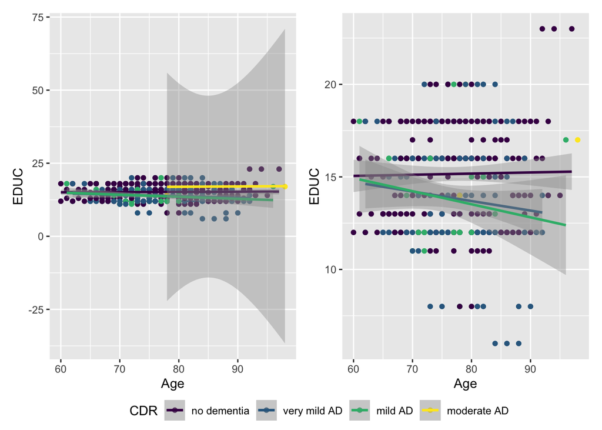

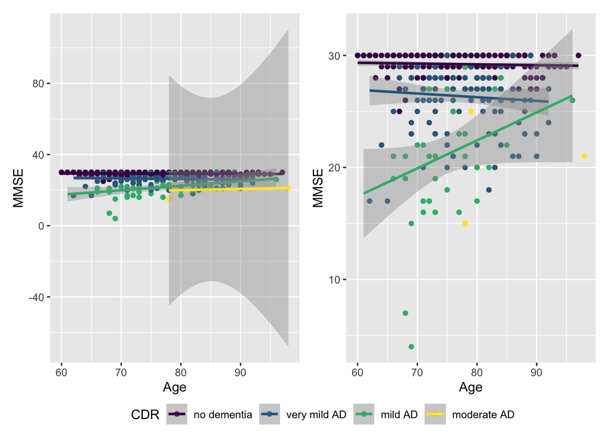

```r
# To be able to create a multitude of plots with different y-axis values I created a function for the plots and used a loop (lapply) to create them.

plotAgeAssociation <- function(yaxis) {
  # create complete cases dataset
  dt.plot <- dt %>%
    dplyr::select(Age, as.name(yaxis), CDR) %>%
    filter(complete.cases(.))

  # 1st plot including all CDR groups
  plot1 <- ggplot(data=dt.plot, aes_(x=~Age, y=as.name(yaxis), color=~CDR)) +
    geom_point() +
    geom_smooth(method = lm) +
    theme(legend.position = "bottom")

  # 2nd plot excluding the moderate AD CDR group to visualise the associations of the other groups better
  plot2 <- ggplot(data=dt.plot, aes_(x=~Age, y=as.name(yaxis), color=~CDR)) +
    geom_point() +
    geom_smooth(method = lm,
                data=dt.plot%>%filter(CDR!="moderate AD"),
                aes_(x=~Age, y=as.name(yaxis), color=~CDR)) +
    theme(legend.position="none")

  # save the legend separately to have just one joint legend below the plots
  legend <- ggpubr::as_ggplot(ggpubr::get_legend(plot1))

  # summarise both plots and the legend to one combined figure
  plot(((plot1 +
           theme(legend.position="none")) +
          plot2)/
         legend +
         plot_layout(width = c(1,1), heights = c(13, 1)))

  # remove the single plots 1 and 2
  rm(plot1); rm(plot2)
}

# run functions for education and MMSE on the y-axis
invisible(lapply(c("EDUC", "MMSE"), plotAgeAssociation))
```

## Show how MMSE performance changes with time?

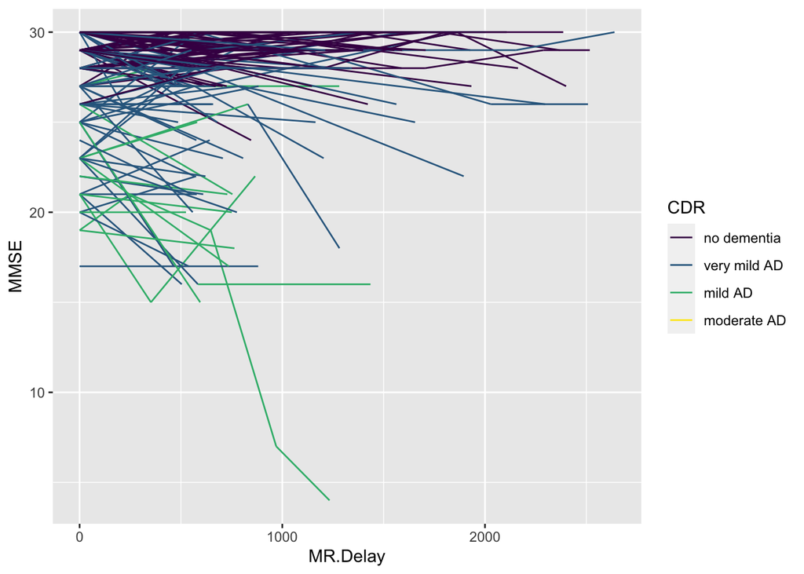

```r
dt %>%
  dplyr::select(Subject.ID, MR.Delay, MMSE, CDR) %>%
  filter(complete.cases(.)) %>%
  ggplot(aes(x = MR.Delay, y = MMSE, color = CDR, group = Subject.ID)) +
  geom_line()
```

## How do age, sex, education and CDR associate with MMSE performance for the first visit?

Create a regression model with MMSE as the outcome and age, sex, education and CDR as the independents. Use the no dementia group as reference group for CDR.

```r
model <- lm(MMSE ~ Age + M.F + EDUC + relevel(factor(CDR, ordered=FALSE), ref = "no dementia"),
            data = dt %>% filter(Visit == 1))
```

### Assumption check

```r
kable(moments::skewness(model$residuals) %>%
        data.frame() %>%
        dplyr::rename("Skewness of residuals" = "."),
      caption = "Skewness of model residuals")
```

Skewness of model residuals

| Skewness of residuals |
| --- |
| -0.6230355 |

```r
kable(car::vif(model),
      caption = "Variance-inflation factors to assess multicolinearity of model independents")
```

Variance-inflation factors to assess multicolinearity of model independents

|  | GVIF | Df | GVIF^(1/(2*Df)) |
| --- | --- | --- | --- |
| Age | 1.013001 | 1 | 1.006480 |
| M.F | 1.096688 | 1 | 1.047228 |
| EDUC | 1.109618 | 1 | 1.053384 |
| relevel(factor(CDR, ordered = FALSE), ref = “no dementia”) | 1.180960 | 2 | 1.042459 |

Plots to check other regression model assumptions

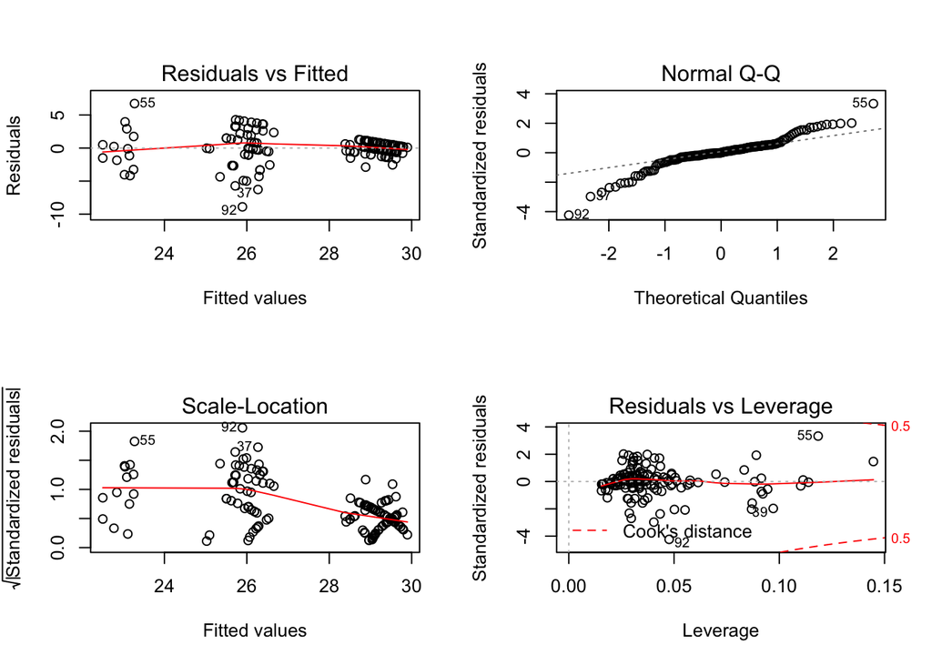

```r
par(mfrow = c(2,2)) # Change the panel layout to 2 x 2
plot(model)
```

### Result table

```r
# Creating data frame including all results
result<- broom::tidy(model, conf.int = TRUE, conf.level = 0.95)
result$N <- model$residuals %>% length()
result$r.squared <- summary(model)$r.squared

# Modify outcome for export
result %>%
  dplyr::rename(independent = term) %>%
  dplyr::mutate(
    independent = dplyr::recode(independent,
                         M.FM = 'Sex (ref. women)',
                         EDUC = 'Education (in years)',
                         'relevel(factor(CDR, ordered = FALSE), ref = \"no dementia\")mild AD' = 'CDR (ref. no dementia) mild AD',
                         'relevel(factor(CDR, ordered = FALSE), ref = \"no dementia\")very mild AD' = 'CDR (ref. no dementia) very mild AD')) %>%
  kable(., caption = "Outcome: MMSE")
```

Outcome: MMSE

| independent | estimate | std.error | statistic | p.value | conf.low | conf.high | N | r.squared |
| --- | --- | --- | --- | --- | --- | --- | --- | --- |
| (Intercept) | 29.7385955 | 2.1132992 | 14.0721178 | 0.0000000 | 25.5615010 | 33.9156901 | 150 | 0.4925347 |
| Age | -0.0193958 | 0.0235059 | -0.8251478 | 0.4106525 | -0.0658569 | 0.0270653 | 150 | 0.4925347 |
| Sex (ref. women) | -0.5643029 | 0.3735060 | -1.5108268 | 0.1330239 | -1.3025656 | 0.1739598 | 150 | 0.4925347 |
| Education (in years) | 0.0734499 | 0.0645724 | 1.1374816 | 0.2572262 | -0.0541822 | 0.2010820 | 150 | 0.4925347 |
| CDR (ref. no dementia) very mild AD | -2.9600498 | 0.4106085 | -7.2089344 | 0.0000000 | -3.7716484 | -2.1484513 | 150 | 0.4925347 |
| CDR (ref. no dementia) mild AD | -6.0383328 | 0.6489159 | -9.3052631 | 0.0000000 | -7.3209637 | -4.7557019 | 150 | 0.4925347 |

## References R session information

```r
citation()
```

```
##
##
##   R Core Team (2020). R: A language and environment for statistical
##   computing. R Foundation for Statistical Computing, Vienna, Austria.
##   URL https://www.R-project.org/.
##
## A BibTeX entry for LaTeX users is
##
##   @Manual{,
##     title = {R: A Language and Environment for Statistical Computing},
##     author = {{R Core Team}},
##     organization = {R Foundation for Statistical Computing},
##     address = {Vienna, Austria},
##     year = {2020},
##     url = {https://www.R-project.org/},
##   }
##
## We have invested a lot of time and effort in creating R, please cite it
## when using it for data analysis. See also 'citation("pkgname")' for
## citing R packages.
```

```r
lapply(list.of.packages, citation)
```

```
## [[1]]
##
##
##   Thomas Lin Pedersen (2020). patchwork: The Composer of Plots. R
##   package version 1.1.1. https://CRAN.R-project.org/package=patchwork
##
## A BibTeX entry for LaTeX users is
##
##   @Manual{,
##     title = {patchwork: The Composer of Plots},
##     author = {Thomas Lin Pedersen},
##     year = {2020},
##     note = {R package version 1.1.1},
##     url = {https://CRAN.R-project.org/package=patchwork},
##   }
##
##
## [[2]]
##
##
##   Alboukadel Kassambara (2020). ggpubr: 'ggplot2' Based Publication
##   Ready Plots. R package version 0.4.0.
##   https://CRAN.R-project.org/package=ggpubr
##
## A BibTeX entry for LaTeX users is
##
##   @Manual{,
##     title = {ggpubr: 'ggplot2' Based Publication Ready Plots},
##     author = {Alboukadel Kassambara},
##     year = {2020},
##     note = {R package version 0.4.0},
##     url = {https://CRAN.R-project.org/package=ggpubr},
##   }
##
##
## [[3]]
##
##   Wickham et al., (2019). Welcome to the tidyverse. Journal of Open
##   Source Software, 4(43), 1686, https://doi.org/10.21105/joss.01686
##
```

[output cut: 152 more lines]

```
##   John Fox and Sanford Weisberg (2019). An {R} Companion to Applied
##   Regression, Third Edition. Thousand Oaks CA: Sage. URL:
##   https://socialsciences.mcmaster.ca/jfox/Books/Companion/
##
## A BibTeX entry for LaTeX users is
##
##   @Book{,
##     title = {An {R} Companion to Applied Regression},
##     edition = {Third},
##     author = {John Fox and Sanford Weisberg},
##     year = {2019},
##     publisher = {Sage},
##     address = {Thousand Oaks {CA}},
##     url = {https://socialsciences.mcmaster.ca/jfox/Books/Companion/},
##   }
```

```r
#RStudio.Version()[-2] #both functions are not working in
#rstudioapi::versionInfo()[-2]
## both functions for the R Studio version are not working in R markdown. Run this code in the console and enter in manually.
```

To cite RStudio in publications use: RStudio Team (2019). RStudio: Integrated Development for R. RStudio, Inc., Boston, MA URL http://www.rstudio.com/.version Version: 1.2.5033 Release name: “Orange Blossom”